# Class Activity, November 17

## Setup

In this activity, we will revisit the `MedGPA` data, which looks at the relationship between GPA, MCAT score, and admission to medical school for 55 students from a midwestern liberal arts college.

Download the activity template: [activity template](https://sta112-f21.github.io/class_activities/ca_lecture_36_template.Rmd)

## Exercises

**Question:** If you know an applicant’s MCAT score, does their GPA provide additional information about their chances of enrollment?

We suspect that the answer is yes – students with both a high MCAT and high GPA are probably more likely to get into med school than students with a high MCAT and low GPA. To explore this question, we will ultimately fit a logistic regression model with both MCAT and GPA as predictors. In this class activity, we will go through the model building process.

Let’s start by making empirical log-odds plots to check that it is reasonable to model the log-odds as a linear function of GPA and MCAT score.

1. Below are empirical log-odds plots for GPA and MCAT score. Based on the plots, does it seem reasonable to model the log-odds as a linear function of GPA and MCAT score?

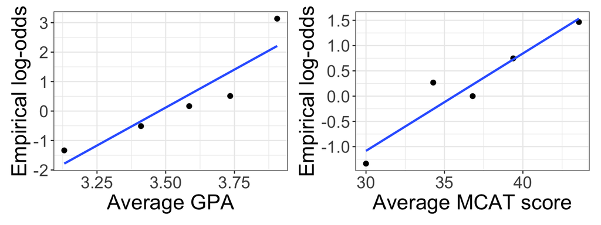

Now, answering our question above involves fitting a model with both GPA and MCAT score as predictors. There are a couple possible models:

$(1) \hspace{1cm} \log \left( \dfrac{\pi}{1 - \pi} \right) = \beta_0 + \beta_1 \ \text{GPA} + \beta_2 \ \text{MCAT}$

$(2) \hspace{1cm} \log \left( \dfrac{\pi}{1 - \pi} \right) = \beta_0 + \beta_1 \ \text{GPA} + \beta_2 \ \text{MCAT} + \beta_3 \ \text{GPA} \cdot \text{MCAT}$

We can try to investigate whether an interaction is necessary by comparing higher MCAT scores (say, above 35) to lower scores. The empirical log-odds plot below shows how the relationship between the log-odds and GPA, for the different MCAT score ranges.

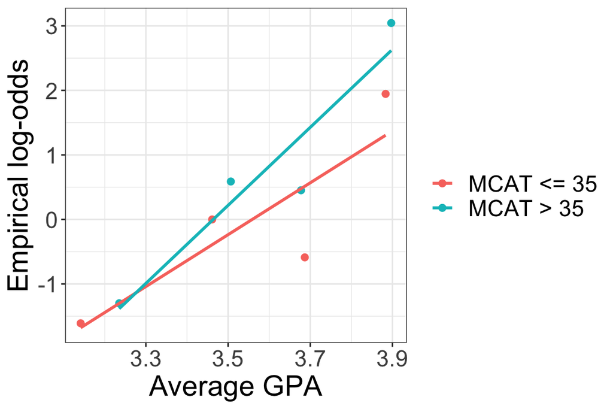

2. Based on the empirical log-odds plot, which model ((1) or (2)) do you think would better fit the data?
3. Fit the selected model, and report the deviance and the equation of the estimated model.
4. What reduced model could we compare against to answer the research question?
5. Fit the reduced model from Exercise 4, and report the deviance and the equation of the fitted model.
6. What is the drop in deviance from the reduced to the full model?